# MR V.S. 2sls (F30)

## 3.4 Comparison of power

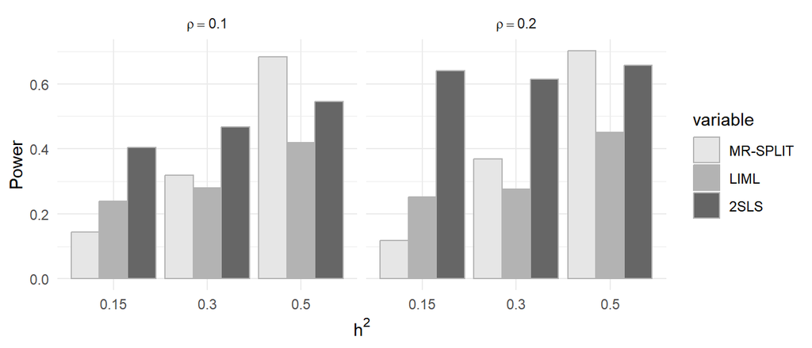

Comparison of power between MR-SPLIT, LIML and 2SLS when beta=0.08

````markdown
```{r fig.width=7, fig.height=3}
#| fig-cap: Comparison of power between MR-SPLIT, LIML and 2SLS when beta=0.08
#calculate power
power=matrix(0,nrow=6,ncol=5)
colnames(power)=c("sig","squareh","MR-SPLIT","LIML","2SLS")
jj=3
for(ss in 1:2){
      par(mfrow=c(1,3),mar=c(2,2,2,1))
  for(hh in 1:3){
       file=paste0("results/2SLS/sumresult_2sls_ss",ss,"hh_",hh,"jj_",jj,"_.txt")
      data1=read.table(file = file,header = TRUE)
      file=paste0("results/2SLS/F30_sumresultMR_ss",ss,"_jj",jj,"_hh",hh,".txt")
      data2=read.table(file = file,header = TRUE)
      power[3*(ss-1)+hh,]=c(ss,squareh[hh],sum(data2[,4]<0.05)/Times,sum(data1[,8]<0.05)/Times,sum(data1[,4]<0.05)/Times)
    }
  }

power1=as.data.frame(power)
power_long <- reshape2::melt(power1, id.vars = c("squareh", "sig"))
power_long$sig=paste0("rho==",sig[power_long$sig])
ggplot(power_long, aes(x = factor(squareh), y = value, fill = variable)) +
  geom_bar(stat = "identity", position = position_dodge(),color = "#b3b3b3") +
  facet_wrap(~sig, labeller = labeller(sig = label_parsed)) +
  labs(x = expression(h^2), y = "Power") +
  theme(plot.title = element_text(hjust = 0.5)) +
  scale_fill_manual(values = c("#e6e6e6", "#b3b3b3","#666666")) +
  theme_minimal()
```
````

````markdown
```{r}
kable(power1, "html", caption = "Comparison between methods") %>%
  kable_styling()
```
````

Comparison between methods

| sig | squareh | MR-SPLIT | LIML | 2SLS |
| --- | --- | --- | --- | --- |
| 1 | 0.15 | 0.143 | 0.238 | 0.404 |
| 1 | 0.30 | 0.319 | 0.279 | 0.468 |
| 1 | 0.50 | 0.683 | 0.419 | 0.545 |
| 2 | 0.15 | 0.118 | 0.252 | 0.641 |
| 2 | 0.30 | 0.368 | 0.276 | 0.615 |
| 2 | 0.50 | 0.701 | 0.451 | 0.657 |

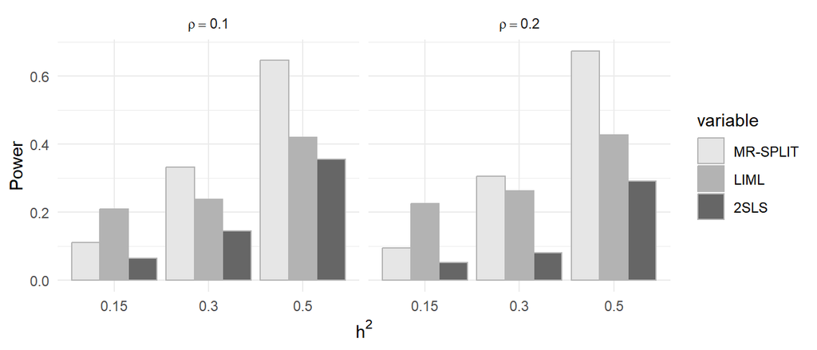

Comparison of power between MR-SPLIT, LIML and 2SLS when beta=-0.08

````markdown
```{r fig.width=7, fig.height=3}
#| fig-cap: Comparison of power between MR-SPLIT, LIML and 2SLS when beta=-0.08
jj=1
for(ss in 1:2){
      par(mfrow=c(1,3),mar=c(2,2,2,1))
  for(hh in 1:3){
       file=paste0("results/2SLS/sumresult_2sls_ss",ss,"hh_",hh,"jj_",jj,"_.txt")
      data1=read.table(file = file,header = TRUE)
      file=paste0("results/2SLS/F30_sumresultMR_ss",ss,"_jj",jj,"_hh",hh,".txt")
      data2=read.table(file = file,header = TRUE)
      power[3*(ss-1)+hh,]=c(ss,squareh[hh],sum(data2[,4]<0.05)/Times,sum(data1[,8]<0.05)/Times,sum(data1[,4]<0.05)/Times)
    }
  }

power1=as.data.frame(power)
power_long <- reshape2::melt(power1, id.vars = c("squareh", "sig"))
power_long$sig=paste0("rho==",sig[power_long$sig])
ggplot(power_long, aes(x = factor(squareh), y = value, fill = variable)) +
  geom_bar(stat = "identity", position = position_dodge(),color="#b3b3b3") +
  facet_wrap(~sig, labeller = labeller(sig = label_parsed)) +
  labs(x = expression(h^2), y = "Power") +
  theme(plot.title = element_text(hjust = 0.5)) +
  scale_fill_manual(values = c("#e6e6e6", "#b3b3b3","#666666")) +
  theme_minimal()
```
````

````markdown
```{r}
kable(power1, "html", caption = "Comparison between methods") %>%
  kable_styling()
```
````

Comparison between methods

| sig | squareh | MR-SPLIT | LIML | 2SLS |
| --- | --- | --- | --- | --- |
| 1 | 0.15 | 0.112 | 0.209 | 0.064 |
| 1 | 0.30 | 0.333 | 0.238 | 0.145 |
| 1 | 0.50 | 0.646 | 0.420 | 0.355 |
| 2 | 0.15 | 0.096 | 0.225 | 0.052 |
| 2 | 0.30 | 0.305 | 0.262 | 0.080 |
| 2 | 0.50 | 0.672 | 0.426 | 0.291 |

## 3.5 Comparison of RMSE

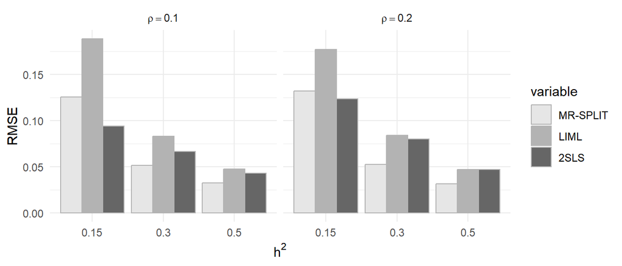

Comparison of RMSE between MR-SPLIT, LIML and 2SLS when beta=0.08

````markdown
```{r fig.width=7, fig.height=3}
#| fig-cap: Comparison of RMSE between MR-SPLIT, LIML and 2SLS when beta=0.08
#calculate RMSE
RMSE=matrix(0,nrow=6,ncol=5)
colnames(RMSE)=c("sig","squareh","MR-SPLIT","LIML","2SLS")
jj=3
for(ss in 1:2){
      par(mfrow=c(1,3),mar=c(2,2,2,1))
  for(hh in 1:3){
       file=paste0("results/2SLS/sumresult_2sls_ss",ss,"hh_",hh,"jj_",jj,"_.txt")
      data1=read.table(file = file,header = TRUE)
      file=paste0("results/2SLS/F30_sumresultMR_ss",ss,"_jj",jj,"_hh",hh,".txt")
      data2=read.table(file = file,header = TRUE)
      RMSE[3*(ss-1)+hh,]=c(ss,squareh[hh],sqrt(mean((data2[,1]-beta[jj])^2)),sqrt(mean((data1[,5]-beta[jj])^2)),sqrt(mean((data1[,1]-beta[jj])^2)))
    }
  }

RMSE1=as.data.frame(RMSE)
RMSE_long <- reshape2::melt(RMSE1, id.vars = c("squareh", "sig"))
RMSE_long$sig=paste0("rho==",sig[RMSE_long$sig])
ggplot(RMSE_long, aes(x = factor(squareh), y = value, fill = variable)) +
  geom_bar(stat = "identity", position = position_dodge(),color="#b3b3b3") +
  facet_wrap(~sig, labeller = labeller(sig = label_parsed)) +
  labs(x = expression(h^2), y = "RMSE") +
  theme(plot.title = element_text(hjust = 0.5)) +
  scale_fill_manual(values = c("#e6e6e6", "#b3b3b3","#666666")) +
  theme_minimal()
```
````

````markdown
```{r}
kable(RMSE1, "html", caption = "Comparison between methods") %>%
  kable_styling()
```
````

Comparison between methods

| sig | squareh | MR-SPLIT | LIML | 2SLS |
| --- | --- | --- | --- | --- |
| 1 | 0.15 | 0.1254803 | 0.1883088 | 0.0941541 |
| 1 | 0.30 | 0.0514460 | 0.0833063 | 0.0667743 |
| 1 | 0.50 | 0.0327598 | 0.0474373 | 0.0431609 |
| 2 | 0.15 | 0.1320026 | 0.1772109 | 0.1237493 |
| 2 | 0.30 | 0.0526310 | 0.0840345 | 0.0799467 |
| 2 | 0.50 | 0.0318755 | 0.0468966 | 0.0470523 |

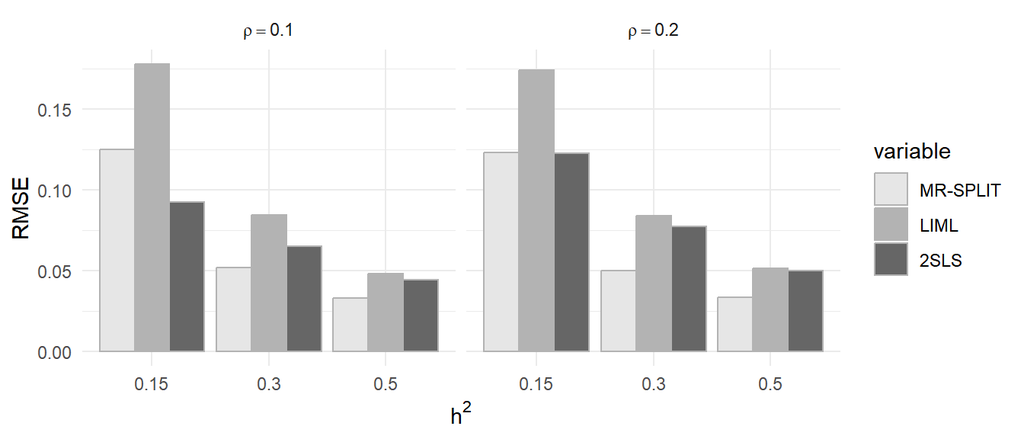

Comparison of RMSE between MR-SPLIT, LIML and 2SLS when beta=-0.08

````markdown
```{r fig.width=7, fig.height=3}
#| fig-cap: Comparison of RMSE between MR-SPLIT, LIML and 2SLS when beta=-0.08
#calculate RMSE
RMSE=matrix(0,nrow=6,ncol=5)
colnames(RMSE)=c("sig","squareh","MR-SPLIT","LIML","2SLS")
jj=1
for(ss in 1:2){
      par(mfrow=c(1,3),mar=c(2,2,2,1))
  for(hh in 1:3){
       file=paste0("results/2SLS/sumresult_2sls_ss",ss,"hh_",hh,"jj_",jj,"_.txt")
      data1=read.table(file = file,header = TRUE)
      file=paste0("results/2SLS/F30_sumresultMR_ss",ss,"_jj",jj,"_hh",hh,".txt")
      data2=read.table(file = file,header = TRUE)
      RMSE[3*(ss-1)+hh,]=c(ss,squareh[hh],sqrt(mean((data2[,1]-beta[jj])^2)),sqrt(mean((data1[,5]-beta[jj])^2)),sqrt(mean((data1[,1]-beta[jj])^2)))
    }
  }

RMSE1=as.data.frame(RMSE)
RMSE_long <- reshape2::melt(RMSE1, id.vars = c("squareh", "sig"))
RMSE_long$sig=paste0("rho==",sig[RMSE_long$sig])
ggplot(RMSE_long, aes(x = factor(squareh), y = value, fill = variable)) +
  geom_bar(stat = "identity", position = position_dodge(),color="#b3b3b3") +
  facet_wrap(~sig, labeller = labeller(sig = label_parsed)) +
  labs(x = expression(h^2), y = "RMSE") +
  theme(plot.title = element_text(hjust = 0.5)) +
  scale_fill_manual(values =  c("#e6e6e6", "#b3b3b3","#666666")) +
  theme_minimal()
```
````

````markdown
```{r}
kable(RMSE1, "html", caption = "Comparison between methods") %>%
  kable_styling()
```
````

Comparison between methods

| sig | squareh | MR-SPLIT | LIML | 2SLS |
| --- | --- | --- | --- | --- |
| 1 | 0.15 | 0.1251644 | 0.1775411 | 0.0925410 |
| 1 | 0.30 | 0.0519445 | 0.0843760 | 0.0650900 |
| 1 | 0.50 | 0.0330838 | 0.0481459 | 0.0443825 |
| 2 | 0.15 | 0.1229096 | 0.1740130 | 0.1225721 |
| 2 | 0.30 | 0.0502562 | 0.0842190 | 0.0776165 |
| 2 | 0.50 | 0.0335487 | 0.0512749 | 0.0501889 |

# 4 Software Information

This section documents information that is important for reproducibility. Most users will not need to read it. It is primarily here for use by the statistician on the team.

We used [R](https://www.r-project.org/) as our main computing environment and [Quarto](https://quarto.org/) scripts to enhance reproducibility. We used RStudio as the editor to interface with R and Quarto.

- Software chain: **qmd file > RStudio > Quarto > R > knitr > md file > Pandoc > html file**.
- Source file: **mr vs 2sls.qmd**
- Output file: **MR V.S. 2sls (F30).html**
- [Quarto 1.4.544](https://quarto.org/) runs `*.qmd` files through [R](https://www.r-project.org/) and [knitr](https://yihui.org/knitr/) to produce `*.md` markdown files.
- [Pandoc 3.1.1](https://pandoc.org) converts markdown files (`*.md`) to other formats, including LaTeX (`*.tex`) and HTML (`*.html`) among others.

## 4.1 Versions